# RC7 -- MI Normalization Fix (Phase 7.4, Audit Gap 5, GH #74)

**Problem:** RC2 Section 3.3 reported MI/H(target) percentages using the Gaussian differential entropy of the target as the denominator. For `fwd_logret_1` on BTCUSDT/dollar bars, H(target) = -2.5371 nats -- **negative**. Dividing MI (always non-negative) by a negative number produces nonsensical "percentages" (negative values or values > 100%).

**Root cause:** For continuous random variables, *differential* entropy can be negative (unlike discrete Shannon entropy which is always >= 0). The Gaussian formula `H(X) = 0.5 * log(2*pi*e*var(X))` goes negative when `var(X) < 1 / (2*pi*e)`, i.e., when variance < ~0.0585. Crypto bar-level log returns have variance on the order of 1e-4, well below this threshold.

**Key insight:** The keep/drop decisions in `validation.py` are based on MI permutation p-values with BH correction -- **not** on MI/H(target) percentages. Therefore, no keep/drop decision is affected by this normalization bug. This notebook verifies that claim and selects a valid normalization for reporting purposes.

**Sections:**

1. Reproduce the problem
2. Evaluate normalization alternatives
3. Choose and apply the fix
4. Updated MI tables
5. Recommendations

```python
"""Cell 0 -- Imports, project root setup, and database connection.

Mirrors the RC7_profiling_closure notebook setup.
"""
from __future__ import annotations

import math
import os
import sys
import warnings
from pathlib import Path

import matplotlib.pyplot as plt
import numpy as np
import pandas as pd
import polars as pl
from IPython.display import display
from scipy import stats as sp_stats
from sklearn.feature_selection import mutual_info_regression

# -- Project root on sys.path ------------------------------------------------
_PROJECT_ROOT: Path = Path(__file__).resolve().parent.parent if "__file__" in dir() else Path.cwd().parent
os.chdir(_PROJECT_ROOT)
if str(_PROJECT_ROOT) not in sys.path:
    sys.path.insert(0, str(_PROJECT_ROOT))

warnings.filterwarnings("ignore", category=FutureWarning)
warnings.filterwarnings("ignore", category=DeprecationWarning)

from src.app.features.application.feature_matrix import FeatureMatrixBuilder
from src.app.features.application.validation import compute_mi_score
from src.app.features.domain.value_objects import FeatureConfig
from src.app.research.application.data_loader import DataLoader
from src.app.research.application.rc2_validation_analysis import (
    compute_target_entropy_gaussian,
)
from src.app.system.database.connection import ConnectionManager

# -- Database connection ------------------------------------------------------
cm: ConnectionManager = ConnectionManager()
cm.initialize()

loader: DataLoader = DataLoader(cm)
builder: FeatureMatrixBuilder = FeatureMatrixBuilder()
feature_config: FeatureConfig = FeatureConfig()

print(f"Project root: {_PROJECT_ROOT}")
print("Database connection initialised.")
```

```
2026-03-27 10:17:01.198 | INFO     | src.app.system.database.connection:initialize:77 - Creating DuckDB engine (path=/home/dmytro-khvedchuk/Desktop/University/Bachelors/RSPCP_bachelors_thesis/data/market.duckdb)
2026-03-27 10:17:01.281 | INFO     | src.app.system.database.connection:initialize:86 - DuckDB connection verified successfully
```

```
Project root: /home/dmytro-khvedchuk/Desktop/University/Bachelors/RSPCP_bachelors_thesis
Database connection initialised.
```

```python
"""Cell 1 -- Data loading helper and canonical combos.

Reuses the same pattern from RC7_profiling_closure.ipynb.
We focus on three key combinations for the analysis:
  - BTCUSDT/dollar (primary, the one RC2 reported)
  - ETHUSDT/dollar (second asset, cross-validation)
  - BTCUSDT/time_1h (baseline bar type)
"""

ASSETS: list[str] = ["BTCUSDT", "ETHUSDT", "LTCUSDT", "SOLUSDT"]

# -- Discover bar config hashes -----------------------------------------------
bar_config_map: dict[tuple[str, str], str] = {}
for _asset in ASSETS:
    configs: list[tuple[str, str]] = loader.get_available_bar_configs(_asset)
    for bar_type_str, config_hash in configs:
        bar_config_map[(_asset, bar_type_str)] = config_hash

print(f"Alternative-bar configs in DB: {len(bar_config_map)}")


def load_bar_data_as_polars(asset: str, bar_type: str) -> pl.DataFrame | None:
    """Load bar data as a Polars DataFrame with standard OHLCV column names."""
    if bar_type == "time_1h":
        df_pd: pd.DataFrame = loader.load_ohlcv(asset, "1h")
        if df_pd.empty:
            return None
        return pl.from_pandas(df_pd)
    key: tuple[str, str] = (asset, bar_type)
    if key not in bar_config_map:
        return None
    df_pd = loader.load_bars(asset, bar_type, bar_config_map[key])
    if df_pd.empty:
        return None
    return pl.from_pandas(df_pd).rename({"start_ts": "timestamp"})


# -- Key combos for this analysis ---------------------------------------------
KEY_COMBOS: list[tuple[str, str]] = [
    ("BTCUSDT", "dollar"),
    ("ETHUSDT", "dollar"),
    ("BTCUSDT", "time_1h"),
]

TARGET_COL: str = "fwd_logret_1"
RANDOM_SEED: int = 42

print(f"Key combos for analysis: {len(KEY_COMBOS)}")
for asset, bt in KEY_COMBOS:
    print(f"  {asset}/{bt}")
```

```
Alternative-bar configs in DB: 36
Key combos for analysis: 3
  BTCUSDT/dollar
  ETHUSDT/dollar
  BTCUSDT/time_1h
```

```python
"""Cell 2 -- Build feature matrices for all key combos.

Uses FeatureMatrixBuilder to produce indicators + targets, then converts
to Pandas for MI computation (ML-research path).
"""

# Store feature matrices (Pandas) and metadata per combo
feature_matrices: dict[tuple[str, str], pd.DataFrame] = {}
feature_names_map: dict[tuple[str, str], list[str]] = {}

for asset, bar_type in KEY_COMBOS:
    df_pl: pl.DataFrame | None = load_bar_data_as_polars(asset, bar_type)
    if df_pl is None:
        print(f"  SKIP {asset}/{bar_type}: no data")
        continue

    fs = builder.build(df_pl, feature_config)
    df_pd: pd.DataFrame = fs.df.to_pandas()
    feat_cols: list[str] = list(fs.feature_columns)

    feature_matrices[(asset, bar_type)] = df_pd
    feature_names_map[(asset, bar_type)] = feat_cols

    print(
        f"  {asset}/{bar_type}: {fs.n_rows_clean} rows, {len(feat_cols)} features, targets: {list(fs.target_columns)}"
    )

print(f"\nLoaded {len(feature_matrices)} feature matrices.")
```

```
  BTCUSDT/dollar: 5164 rows, 23 features, targets: ['fwd_logret_1', 'fwd_logret_24', 'fwd_logret_4', 'fwd_vol_24', 'fwd_vol_4']
  ETHUSDT/dollar: 2636 rows, 23 features, targets: ['fwd_logret_1', 'fwd_logret_24', 'fwd_logret_4', 'fwd_vol_24', 'fwd_vol_4']
  BTCUSDT/time_1h: 54155 rows, 23 features, targets: ['fwd_logret_1', 'fwd_logret_24', 'fwd_logret_4', 'fwd_vol_24', 'fwd_vol_4']

Loaded 3 feature matrices.
```

## Section 1: Reproduce the Problem

We reproduce the exact MI/H(target) computation from RC2 Section 3.3 and show why the normalization is invalid when H(target) is negative.

```python
"""Section 1, Step 1 -- Compute H(target) for each combo and show it is negative.

Uses the same Gaussian upper-bound formula from RC2:
    H(X) = 0.5 * log(2 * pi * e * var(X))

The critical variance threshold where H(X) = 0 is:
    var_crit = 1 / (2 * pi * e) ~ 0.05855
"""

print("=" * 70)
print("SECTION 1: Reproducing the negative H(target) problem")
print("=" * 70)

# Critical variance where Gaussian entropy = 0
var_critical: float = 1.0 / (2.0 * math.pi * math.e)
print(f"\nCritical variance (H=0 boundary): {var_critical:.6f}")
print(f"If var(target) < {var_critical:.6f}, then H(target) < 0 (negative)")
print()

entropy_results: list[dict[str, object]] = []

for (asset, bar_type), df_pd in feature_matrices.items():
    target_arr: np.ndarray = df_pd[TARGET_COL].dropna().to_numpy(dtype=np.float64)
    target_var: float = float(np.var(target_arr))
    target_std: float = float(np.std(target_arr))
    h_target: float = compute_target_entropy_gaussian(target_arr)

    entropy_results.append(
        {
            "Asset": asset,
            "Bar Type": bar_type,
            "N": len(target_arr),
            "Var(target)": target_var,
            "Std(target)": target_std,
            "H(target) nats": h_target,
            "H < 0?": h_target < 0,
            "Var < critical?": target_var < var_critical,
        }
    )

    print(f"{asset}/{bar_type}:")
    print(f"  N = {len(target_arr)}")
    print(f"  var(target) = {target_var:.8f}  (critical = {var_critical:.6f})")
    print(f"  std(target) = {target_std:.6f}")
    print(f"  H(target)   = {h_target:.4f} nats  {'*** NEGATIVE ***' if h_target < 0 else '(positive)'}")
    print()

entropy_df: pd.DataFrame = pd.DataFrame(entropy_results)
display(
    entropy_df.style.format(
        {
            "Var(target)": "{:.8f}",
            "Std(target)": "{:.6f}",
            "H(target) nats": "{:.4f}",
        }
    ).set_caption("Table 1.1: Target Entropy by (Asset, Bar Type)")
)
```

```
======================================================================
SECTION 1: Reproducing the negative H(target) problem
======================================================================

Critical variance (H=0 boundary): 0.058550
If var(target) < 0.058550, then H(target) < 0 (negative)

BTCUSDT/dollar:
  N = 5164
  var(target) = 0.00036626  (critical = 0.058550)
  std(target) = 0.019138
  H(target)   = -2.5371 nats  *** NEGATIVE ***

ETHUSDT/dollar:
  N = 2636
  var(target) = 0.00116389  (critical = 0.058550)
  std(target) = 0.034116
  H(target)   = -1.9591 nats  *** NEGATIVE ***

BTCUSDT/time_1h:
  N = 54155
  var(target) = 0.00004473  (critical = 0.058550)
  std(target) = 0.006688
  H(target)   = -3.5885 nats  *** NEGATIVE ***
```

Table 1.1: Target Entropy by (Asset, Bar Type)

|  | Asset | Bar Type | N | Var(target) | Std(target) | H(target) nats | H < 0? | Var < critical? |
| --- | --- | --- | --- | --- | --- | --- | --- | --- |
| 0 | BTCUSDT | dollar | 5164 | 0.00036626 | 0.019138 | -2.5371 | True | True |
| 1 | ETHUSDT | dollar | 2636 | 0.00116389 | 0.034116 | -1.9591 | True | True |
| 2 | BTCUSDT | time_1h | 54155 | 0.00004473 | 0.006688 | -3.5885 | True | True |

```python
"""Section 1, Step 2 -- Compute raw MI and show the invalid MI/H(target) percentages.

Reproduces the exact computation from RC2's build_mi_table():
    mi_pct = (MI / max(H(target), eps)) * 100.0

When H(target) < 0, max(H(target), 1e-12) = 1e-12, causing MI/H(target)
to be astronomically large (millions of percent). The RC2 code uses eps
protection which masks the problem but produces meaningless numbers.

We also show what happens WITHOUT the eps protection (the mathematically
correct but nonsensical result).
"""

EPS: float = 1e-12  # Same eps as in rc2_validation_analysis.py

print("=" * 70)
print("SECTION 1: Invalid MI/H(target) percentages from RC2")
print("=" * 70)

# Use BTCUSDT/dollar as primary example (same as RC2)
primary_key: tuple[str, str] = ("BTCUSDT", "dollar")
df_primary: pd.DataFrame = feature_matrices[primary_key]
feat_names: list[str] = feature_names_map[primary_key]
target_arr: np.ndarray = df_primary[TARGET_COL].to_numpy(dtype=np.float64)

h_target: float = compute_target_entropy_gaussian(target_arr)
print(f"\nH(target) = {h_target:.4f} nats (NEGATIVE)")
print(f"max(H(target), eps) = {max(h_target, EPS):.12e}")
print()

# Compute MI for each feature
mi_scores: list[float] = []
for j, fname in enumerate(feat_names):
    feat_col: np.ndarray = df_primary[fname].to_numpy(dtype=np.float64)
    mi: float = compute_mi_score(feat_col, target_arr, RANDOM_SEED + j)
    mi_scores.append(mi)

# Build comparison table: RC2's method vs mathematically correct division
invalid_rows: list[dict[str, object]] = []
for fname, mi in zip(feat_names, mi_scores, strict=True):
    # RC2 method: uses max(H, eps) -- eps protection masks the issue
    mi_pct_rc2: float = (mi / max(h_target, EPS)) * 100.0
    # Mathematically correct (but nonsensical when H < 0)
    mi_pct_raw: float = (mi / h_target) * 100.0 if h_target != 0 else float("inf")

    invalid_rows.append(
        {
            "Feature": fname,
            "MI (nats)": mi,
            "H(target)": h_target,
            "MI/H(target) % [correct math]": mi_pct_raw,
            "MI/max(H,eps) % [RC2 code]": mi_pct_rc2,
        }
    )

invalid_df: pd.DataFrame = pd.DataFrame(invalid_rows).sort_values("MI (nats)", ascending=False)

print("--- MI/H(target) using correct math (H is negative) ---")
print("Dividing positive MI by negative H produces NEGATIVE percentages.")
print("This is mathematically correct but semantically meaningless.\n")

display(
    invalid_df.style.format(
        {
            "MI (nats)": "{:.6f}",
            "H(target)": "{:.4f}",
            "MI/H(target) % [correct math]": "{:.3f}",
            "MI/max(H,eps) % [RC2 code]": "{:.1f}",
        }
    ).set_caption(f"Table 1.2: Invalid MI/H(target) -- BTCUSDT/dollar (H(target) = {h_target:.4f} nats)")
)

print(
    f"\nWith correct math: MI/H(target) ranges from {invalid_df['MI/H(target) % [correct math]'].min():.3f}% "
    f"to {invalid_df['MI/H(target) % [correct math]'].max():.3f}%"
)
print("All values are NEGATIVE because MI > 0 and H(target) < 0.")
print(f"\nWith RC2 eps protection: MI/max(H,eps) ranges up to {invalid_df['MI/max(H,eps) % [RC2 code]'].max():.0f}%")
print("Astronomically large because eps = 1e-12 is used as denominator.")
```

```
======================================================================
SECTION 1: Invalid MI/H(target) percentages from RC2
======================================================================

H(target) = -2.5371 nats (NEGATIVE)
max(H(target), eps) = 1.000000000000e-12

--- MI/H(target) using correct math (H is negative) ---
Dividing positive MI by negative H produces NEGATIVE percentages.
This is mathematically correct but semantically meaningless.
```

Table 1.2: Invalid MI/H(target) -- BTCUSDT/dollar (H(target) = -2.5371 nats)

|  | Feature | MI (nats) | H(target) | MI/H(target) % [correct math] | MI/max(H,eps) % [RC2 code] |
| --- | --- | --- | --- | --- | --- |
| 0 | amihud_24 | 0.096231 | -2.5371 | -3.793 | 9623066784597.8 |
| 5 | gk_vol_24 | 0.093117 | -2.5371 | -3.670 | 9311726690770.2 |
| 19 | rv_24 | 0.088846 | -2.5371 | -3.502 | 8884587505369.9 |
| 12 | park_vol_24 | 0.087935 | -2.5371 | -3.466 | 8793498373641.2 |
| 20 | rv_48 | 0.075464 | -2.5371 | -2.974 | 7546357296843.0 |
| 18 | rv_12 | 0.050690 | -2.5371 | -1.998 | 5068974356935.8 |
| 3 | bbwidth_20_2.0 | 0.039595 | -2.5371 | -1.561 | 3959458701617.4 |
| 9 | logret_24 | 0.030073 | -2.5371 | -1.185 | 3007282806656.8 |
| 16 | roc_4 | 0.020807 | -2.5371 | -0.820 | 2080736901129.1 |
| 10 | logret_4 | 0.020431 | -2.5371 | -0.805 | 2043051093960.1 |
| 4 | ema_xover_8_21 | 0.018914 | -2.5371 | -0.745 | 1891411607026.6 |
| 2 | bbpctb_20_2.0 | 0.011640 | -2.5371 | -0.459 | 1164019020138.9 |
| 15 | roc_12 | 0.009758 | -2.5371 | -0.385 | 975769122829.1 |
| 8 | logret_12 | 0.009242 | -2.5371 | -0.364 | 924187339803.8 |
| 21 | slope_14 | 0.004670 | -2.5371 | -0.184 | 467008837068.7 |
| 6 | hurst_100 | 0.000000 | -2.5371 | -0.000 | 0.0 |
| 1 | atr_14 | 0.000000 | -2.5371 | -0.000 | 0.0 |
| 11 | obv_slope_14 | 0.000000 | -2.5371 | -0.000 | 0.0 |
| 7 | logret_1 | 0.000000 | -2.5371 | -0.000 | 0.0 |
| 14 | roc_1 | 0.000000 | -2.5371 | -0.000 | 0.0 |
| 13 | ret_zscore_24 | 0.000000 | -2.5371 | -0.000 | 0.0 |
| 17 | rsi_14 | 0.000000 | -2.5371 | -0.000 | 0.0 |
| 22 | vol_zscore_24 | 0.000000 | -2.5371 | -0.000 | 0.0 |

```
With correct math: MI/H(target) ranges from -3.793% to -0.000%
All values are NEGATIVE because MI > 0 and H(target) < 0.

With RC2 eps protection: MI/max(H,eps) ranges up to 9623066784598%
Astronomically large because eps = 1e-12 is used as denominator.
```

```python
"""Section 1, Step 3 -- Verify that keep/drop decisions are NOT affected.

The validation pipeline (validation.py) uses MI permutation p-values with
BH correction for significance, NOT MI/H(target) percentages. The percentage
column was purely for reporting/interpretation in the thesis table.

We verify this by checking what the validation code actually uses.
"""

print("=" * 70)
print("SECTION 1: Verification that keep/drop decisions are unaffected")
print("=" * 70)

print("""
How validation.py determines keep/drop:
  1. Compute raw MI(feature, target) using sklearn mutual_info_regression
  2. Build null distribution by block-permuting target (1000 shuffles)
  3. Compute empirical p-value: p = (count(null >= observed) + 1) / (N + 1)
  4. Apply Benjamini-Hochberg correction across all features
  5. Feature passes MI gate if BH-corrected p < 0.05

  ==> MI p-values depend on raw MI scores and null distributions
  ==> H(target) is NEVER used in validation.py
  ==> The MI/H(target) column exists ONLY in rc2_validation_analysis.py::build_mi_table()
  ==> It is a DISPLAY-ONLY column for thesis reporting

CONCLUSION: Zero keep/drop decisions are affected by the normalization bug.
The bug is confined to the interpretation/display layer.
""")

# Verify by reading the function signatures
import inspect
from src.app.features.application.validation import FeatureValidator

mi_test_source: str = inspect.getsource(FeatureValidator._run_mi_test)
uses_entropy: bool = "entropy" in mi_test_source.lower() or "h_target" in mi_test_source.lower()
print(f"FeatureValidator._run_mi_test references entropy: {uses_entropy}")
print("  (Expected: False -- entropy is not used in the validation pipeline)")

from src.app.research.application.rc2_validation_analysis import RC2ValidationAnalyzer

mi_table_source: str = inspect.getsource(RC2ValidationAnalyzer.build_mi_table)
uses_entropy_display: bool = "target_entropy" in mi_table_source
print(f"\nRC2ValidationAnalyzer.build_mi_table references target_entropy: {uses_entropy_display}")
print("  (Expected: True -- entropy is used only for the display percentage column)")
```

```
======================================================================
SECTION 1: Verification that keep/drop decisions are unaffected
======================================================================

How validation.py determines keep/drop:
  1. Compute raw MI(feature, target) using sklearn mutual_info_regression
  2. Build null distribution by block-permuting target (1000 shuffles)
  3. Compute empirical p-value: p = (count(null >= observed) + 1) / (N + 1)
  4. Apply Benjamini-Hochberg correction across all features
  5. Feature passes MI gate if BH-corrected p < 0.05

  ==> MI p-values depend on raw MI scores and null distributions
  ==> H(target) is NEVER used in validation.py
  ==> The MI/H(target) column exists ONLY in rc2_validation_analysis.py::build_mi_table()
  ==> It is a DISPLAY-ONLY column for thesis reporting

CONCLUSION: Zero keep/drop decisions are affected by the normalization bug.
The bug is confined to the interpretation/display layer.

FeatureValidator._run_mi_test references entropy: False
  (Expected: False -- entropy is not used in the validation pipeline)

RC2ValidationAnalyzer.build_mi_table references target_entropy: True
  (Expected: True -- entropy is used only for the display percentage column)
```

## Section 2: Evaluate Normalization Alternatives

We evaluate four candidate approaches:

1. **Raw MI (nats)** -- no normalization, valid for ranking features
2. **MI / H_disc(feature)** -- normalize by discretized feature entropy (always positive)
3. **NMI = MI / sqrt(H_disc(feature) * H_disc(target))** -- geometric mean normalization using discretized entropies
4. **MI / log(N)** -- normalize by maximum possible discrete entropy

For options 2-4, we discretize continuous variables into histogram bins to compute *discrete* Shannon entropy (always non-negative), avoiding the negative differential entropy problem entirely.

```python
"""Section 2, Step 1 -- Compute discrete Shannon entropy for features and target.

Discretize using Sturges' rule (k = 1 + log2(N) bins) to compute discrete
Shannon entropy H = -sum(p * log(p)). This is always >= 0.

We also compute H_disc(target) using the same approach, which will be positive
unlike the Gaussian differential entropy.
"""

print("=" * 70)
print("SECTION 2: Evaluating normalization alternatives")
print("=" * 70)


def compute_discrete_entropy(arr: np.ndarray, n_bins: int | None = None) -> float:
    """Compute discrete Shannon entropy via histogram binning.

    Uses Sturges' rule for bin count if not specified.
    Returns entropy in nats (natural log).

    Args:
        arr: 1-D array of continuous values.
        n_bins: Number of histogram bins. If None, uses Sturges' rule.

    Returns:
        Discrete Shannon entropy in nats (always >= 0).
    """
    if len(arr) < 2:
        return 0.0
    if n_bins is None:
        n_bins = max(int(1 + np.log2(len(arr))), 2)
    counts: np.ndarray
    counts, _ = np.histogram(arr, bins=n_bins)
    # Normalise to probabilities, filter zeros
    probs: np.ndarray = counts / counts.sum()
    probs = probs[probs > 0]
    return float(-np.sum(probs * np.log(probs)))


# Compute for BTCUSDT/dollar (primary)
df_primary = feature_matrices[primary_key]
feat_names = feature_names_map[primary_key]
target_arr = df_primary[TARGET_COL].to_numpy(dtype=np.float64)

n_samples: int = len(target_arr)
n_bins_sturges: int = max(int(1 + np.log2(n_samples)), 2)

print(f"\nN samples: {n_samples}")
print(f"Sturges' bins: {n_bins_sturges}")
print(f"Max discrete entropy: log({n_bins_sturges}) = {np.log(n_bins_sturges):.4f} nats")
print()

# Discrete H(target)
h_target_disc: float = compute_discrete_entropy(target_arr, n_bins_sturges)
print(f"H_disc(target): {h_target_disc:.4f} nats (POSITIVE, as expected)")
print(f"H_gauss(target): {compute_target_entropy_gaussian(target_arr):.4f} nats (NEGATIVE)")
print()

# Discrete H(feature) for each feature
h_feature_disc: dict[str, float] = {}
for fname in feat_names:
    feat_col: np.ndarray = df_primary[fname].to_numpy(dtype=np.float64)
    h_feat: float = compute_discrete_entropy(feat_col, n_bins_sturges)
    h_feature_disc[fname] = h_feat

h_feat_series: pd.Series = pd.Series(h_feature_disc).sort_values(ascending=False)
print("Discrete feature entropies (nats):")
for fname, h_val in h_feat_series.items():
    print(f"  {fname:25s} H_disc = {h_val:.4f}")

print(f"\nAll H_disc(feature) > 0: {all(v > 0 for v in h_feature_disc.values())}")
print(f"Min H_disc(feature): {min(h_feature_disc.values()):.4f}")
print(f"Max H_disc(feature): {max(h_feature_disc.values()):.4f}")
```

```
======================================================================
SECTION 2: Evaluating normalization alternatives
======================================================================

N samples: 5164
Sturges' bins: 13
Max discrete entropy: log(13) = 2.5649 nats

H_disc(target): 1.6214 nats (POSITIVE, as expected)
H_gauss(target): -2.5371 nats (NEGATIVE)

Discrete feature entropies (nats):
  bbpctb_20_2.0             H_disc = 2.2364
  ema_xover_8_21            H_disc = 2.1629
  rv_48                     H_disc = 2.1304
  rv_24                     H_disc = 2.0655
  park_vol_24               H_disc = 2.0429
  rv_12                     H_disc = 2.0149
  gk_vol_24                 H_disc = 1.9929
  amihud_24                 H_disc = 1.9840
  bbwidth_20_2.0            H_disc = 1.9411
  ret_zscore_24             H_disc = 1.9164
  vol_zscore_24             H_disc = 1.8701
  logret_24                 H_disc = 1.8637
  roc_12                    H_disc = 1.8309
  logret_12                 H_disc = 1.8014
  roc_4                     H_disc = 1.7925
  logret_4                  H_disc = 1.7853
  roc_1                     H_disc = 1.6295
  logret_1                  H_disc = 1.6212
  hurst_100                 H_disc = 1.2264
  slope_14                  H_disc = 0.8682
  obv_slope_14              H_disc = 0.6973
  atr_14                    H_disc = -0.0000
  rsi_14                    H_disc = -0.0000

All H_disc(feature) > 0: False
Min H_disc(feature): -0.0000
Max H_disc(feature): 2.2364
```

```python
"""Section 2, Step 2 -- Compute all four normalization candidates.

For each feature, compute:
  1. Raw MI (nats)
  2. MI / H_disc(feature)  -- fraction of feature uncertainty shared with target
  3. NMI = MI / sqrt(H_disc(feature) * H_disc(target))  -- geometric mean NMI
  4. MI / log(N_bins)  -- fraction of max possible discrete entropy
"""

h_max: float = float(np.log(n_bins_sturges))

norm_rows: list[dict[str, object]] = []
for fname, mi in zip(feat_names, mi_scores, strict=True):
    h_feat: float = h_feature_disc[fname]

    # Option 1: Raw MI
    raw_mi: float = mi

    # Option 2: MI / H_disc(feature)
    mi_over_h_feat: float = (mi / h_feat * 100.0) if h_feat > 0 else 0.0

    # Option 3: NMI geometric mean
    denom_geom: float = math.sqrt(h_feat * h_target_disc) if (h_feat > 0 and h_target_disc > 0) else 0.0
    nmi_geom: float = (mi / denom_geom * 100.0) if denom_geom > 0 else 0.0

    # Option 4: MI / log(N_bins)
    mi_over_h_max: float = (mi / h_max * 100.0) if h_max > 0 else 0.0

    norm_rows.append(
        {
            "Feature": fname,
            "MI (nats)": raw_mi,
            "H_disc(feat)": h_feat,
            "MI/H_disc(feat) %": mi_over_h_feat,
            "NMI_geom %": nmi_geom,
            "MI/log(k) %": mi_over_h_max,
        }
    )

norm_df: pd.DataFrame = pd.DataFrame(norm_rows).sort_values("MI (nats)", ascending=False)

display(
    norm_df.style.format(
        {
            "MI (nats)": "{:.6f}",
            "H_disc(feat)": "{:.4f}",
            "MI/H_disc(feat) %": "{:.4f}",
            "NMI_geom %": "{:.4f}",
            "MI/log(k) %": "{:.4f}",
        }
    ).set_caption("Table 2.1: Four Normalization Candidates -- BTCUSDT/dollar")
)

print("\nAll normalized values are non-negative and bounded [0, 100%].")
print("Options 2-4 avoid the negative entropy problem entirely.")
```

Table 2.1: Four Normalization Candidates -- BTCUSDT/dollar

|  | Feature | MI (nats) | H_disc(feat) | MI/H_disc(feat) % | NMI_geom % | MI/log(k) % |
| --- | --- | --- | --- | --- | --- | --- |
| 0 | amihud_24 | 0.096231 | 1.9840 | 4.8503 | 5.3654 | 3.7518 |
| 5 | gk_vol_24 | 0.093117 | 1.9929 | 4.6725 | 5.1802 | 3.6304 |
| 19 | rv_24 | 0.088846 | 2.0655 | 4.3014 | 4.8550 | 3.4638 |
| 12 | park_vol_24 | 0.087935 | 2.0429 | 4.3043 | 4.8316 | 3.4283 |
| 20 | rv_48 | 0.075464 | 2.1304 | 3.5423 | 4.0604 | 2.9421 |
| 18 | rv_12 | 0.050690 | 2.0149 | 2.5157 | 2.8045 | 1.9762 |
| 3 | bbwidth_20_2.0 | 0.039595 | 1.9411 | 2.0398 | 2.2319 | 1.5437 |
| 9 | logret_24 | 0.030073 | 1.8637 | 1.6136 | 1.7300 | 1.1725 |
| 16 | roc_4 | 0.020807 | 1.7925 | 1.1608 | 1.2205 | 0.8112 |
| 10 | logret_4 | 0.020431 | 1.7853 | 1.1444 | 1.2008 | 0.7965 |
| 4 | ema_xover_8_21 | 0.018914 | 2.1629 | 0.8745 | 1.0100 | 0.7374 |
| 2 | bbpctb_20_2.0 | 0.011640 | 2.2364 | 0.5205 | 0.6113 | 0.4538 |
| 15 | roc_12 | 0.009758 | 1.8309 | 0.5330 | 0.5663 | 0.3804 |
| 8 | logret_12 | 0.009242 | 1.8014 | 0.5130 | 0.5408 | 0.3603 |
| 21 | slope_14 | 0.004670 | 0.8682 | 0.5379 | 0.3936 | 0.1821 |
| 6 | hurst_100 | 0.000000 | 1.2264 | 0.0000 | 0.0000 | 0.0000 |
| 1 | atr_14 | 0.000000 | -0.0000 | 0.0000 | 0.0000 | 0.0000 |
| 11 | obv_slope_14 | 0.000000 | 0.6973 | 0.0000 | 0.0000 | 0.0000 |
| 7 | logret_1 | 0.000000 | 1.6212 | 0.0000 | 0.0000 | 0.0000 |
| 14 | roc_1 | 0.000000 | 1.6295 | 0.0000 | 0.0000 | 0.0000 |
| 13 | ret_zscore_24 | 0.000000 | 1.9164 | 0.0000 | 0.0000 | 0.0000 |
| 17 | rsi_14 | 0.000000 | -0.0000 | 0.0000 | 0.0000 | 0.0000 |
| 22 | vol_zscore_24 | 0.000000 | 1.8701 | 0.0000 | 0.0000 | 0.0000 |

```
All normalized values are non-negative and bounded [0, 100%].
Options 2-4 avoid the negative entropy problem entirely.
```

```python
"""Section 2, Step 3 -- Compare rankings: Spearman correlation between methods.

If all normalization methods produce the same ranking of features, then the
choice of normalization is irrelevant for feature selection -- only the
interpretability of the absolute values differs.
"""

from scipy.stats import spearmanr

# Extract ranking vectors
rank_raw: np.ndarray = sp_stats.rankdata(-norm_df["MI (nats)"].to_numpy())  # negative for descending
rank_h_feat: np.ndarray = sp_stats.rankdata(-norm_df["MI/H_disc(feat) %"].to_numpy())
rank_nmi_geom: np.ndarray = sp_stats.rankdata(-norm_df["NMI_geom %"].to_numpy())
rank_h_max: np.ndarray = sp_stats.rankdata(-norm_df["MI/log(k) %"].to_numpy())

methods: list[str] = ["Raw MI", "MI/H(feat)", "NMI_geom", "MI/log(k)"]
rank_arrays: list[np.ndarray] = [rank_raw, rank_h_feat, rank_nmi_geom, rank_h_max]

# Spearman correlation matrix
corr_matrix: np.ndarray = np.zeros((4, 4))
pval_matrix: np.ndarray = np.zeros((4, 4))

for i in range(4):
    for j in range(4):
        rho: float
        pval: float
        rho, pval = spearmanr(rank_arrays[i], rank_arrays[j])
        corr_matrix[i, j] = rho
        pval_matrix[i, j] = pval

corr_df: pd.DataFrame = pd.DataFrame(corr_matrix, index=methods, columns=methods)
pval_df: pd.DataFrame = pd.DataFrame(pval_matrix, index=methods, columns=methods)

print("Spearman rank correlation between normalization methods:")
print("(rho = 1.0 means identical ranking)\n")
display(
    corr_df.style.format("{:.4f}")
    .background_gradient(cmap="RdYlGn", vmin=0.8, vmax=1.0)
    .set_caption("Table 2.2: Spearman Rank Correlation Between Normalization Methods")
)

print("\nKey observations:")
print(f"  Raw MI vs MI/H(feat):  rho = {corr_matrix[0, 1]:.4f}")
print(f"  Raw MI vs NMI_geom:    rho = {corr_matrix[0, 2]:.4f}")
print(f"  Raw MI vs MI/log(k):   rho = {corr_matrix[0, 3]:.4f}")

# Check if raw MI and MI/log(k) produce IDENTICAL rankings
raw_mi_rank: np.ndarray = sp_stats.rankdata(-norm_df["MI (nats)"].to_numpy())
log_k_rank: np.ndarray = sp_stats.rankdata(-norm_df["MI/log(k) %"].to_numpy())
identical_to_raw: bool = np.array_equal(raw_mi_rank, log_k_rank)
print(f"\n  Raw MI and MI/log(k) produce identical rankings: {identical_to_raw}")
print("  (Expected: True -- dividing by a constant does not change ranking)")
```

```
Spearman rank correlation between normalization methods:
(rho = 1.0 means identical ranking)
```

Table 2.2: Spearman Rank Correlation Between Normalization Methods

|  | Raw MI | MI/H(feat) | NMI_geom | MI/log(k) |
| --- | --- | --- | --- | --- |
| Raw MI | 1.0000 | 0.9918 | 1.0000 | 1.0000 |
| MI/H(feat) | 0.9918 | 1.0000 | 0.9918 | 0.9918 |
| NMI_geom | 1.0000 | 0.9918 | 1.0000 | 1.0000 |
| MI/log(k) | 1.0000 | 0.9918 | 1.0000 | 1.0000 |

```
Key observations:
  Raw MI vs MI/H(feat):  rho = 0.9918
  Raw MI vs NMI_geom:    rho = 1.0000
  Raw MI vs MI/log(k):   rho = 1.0000

  Raw MI and MI/log(k) produce identical rankings: True
  (Expected: True -- dividing by a constant does not change ranking)
```

```python
"""Section 2, Step 4 -- Cross-validate on ETHUSDT/dollar and BTCUSDT/time_1h.

Verify that the ranking stability holds across different (asset, bar_type) combos.
"""

print("=" * 70)
print("Cross-validation of normalization ranking stability")
print("=" * 70)

for combo_key in [("ETHUSDT", "dollar"), ("BTCUSDT", "time_1h")]:
    if combo_key not in feature_matrices:
        print(f"\n  SKIP {combo_key[0]}/{combo_key[1]}: not loaded")
        continue

    df_combo: pd.DataFrame = feature_matrices[combo_key]
    feat_names_combo: list[str] = feature_names_map[combo_key]
    target_combo: np.ndarray = df_combo[TARGET_COL].to_numpy(dtype=np.float64)
    n_combo: int = len(target_combo)
    n_bins_combo: int = max(int(1 + np.log2(n_combo)), 2)

    # H(target) -- both Gaussian and discrete
    h_tgt_gauss: float = compute_target_entropy_gaussian(target_combo)
    h_tgt_disc: float = compute_discrete_entropy(target_combo, n_bins_combo)

    # MI and H_disc(feature) for each feature
    mi_combo: list[float] = []
    h_feat_combo: list[float] = []
    for j, fname in enumerate(feat_names_combo):
        feat_col = df_combo[fname].to_numpy(dtype=np.float64)
        mi_val: float = compute_mi_score(feat_col, target_combo, RANDOM_SEED + j)
        mi_combo.append(mi_val)
        h_feat_combo.append(compute_discrete_entropy(feat_col, n_bins_combo))

    mi_arr: np.ndarray = np.array(mi_combo)
    h_feat_arr: np.ndarray = np.array(h_feat_combo)

    # Rankings
    rank_raw_combo: np.ndarray = sp_stats.rankdata(-mi_arr)
    # MI / H_disc(feature)
    mi_over_hf: np.ndarray = np.where(h_feat_arr > 0, mi_arr / h_feat_arr, 0.0)
    rank_hf_combo: np.ndarray = sp_stats.rankdata(-mi_over_hf)

    rho_combo: float
    rho_combo, _ = spearmanr(rank_raw_combo, rank_hf_combo)

    print(f"\n{combo_key[0]}/{combo_key[1]}:")
    print(f"  N = {n_combo}, bins = {n_bins_combo}")
    print(f"  H_gauss(target) = {h_tgt_gauss:.4f} nats {'(NEGATIVE)' if h_tgt_gauss < 0 else '(positive)'}")
    print(f"  H_disc(target)  = {h_tgt_disc:.4f} nats (always positive)")
    print(f"  Spearman(Raw MI, MI/H_disc(feat)): rho = {rho_combo:.4f}")

print("\n--- Summary ---")
print("If rho is close to 1.0 across all combos, MI/H_disc(feat) adds no")
print("ranking information beyond raw MI. Feature selection is unchanged.")
```

```
======================================================================
Cross-validation of normalization ranking stability
======================================================================

ETHUSDT/dollar:
  N = 2636, bins = 12
  H_gauss(target) = -1.9591 nats (NEGATIVE)
  H_disc(target)  = 1.6955 nats (always positive)
  Spearman(Raw MI, MI/H_disc(feat)): rho = 0.9399
```

```
BTCUSDT/time_1h:
  N = 54155, bins = 16
  H_gauss(target) = -3.5885 nats (NEGATIVE)
  H_disc(target)  = 0.6641 nats (always positive)
  Spearman(Raw MI, MI/H_disc(feat)): rho = 0.9248

--- Summary ---
If rho is close to 1.0 across all combos, MI/H_disc(feat) adds no
ranking information beyond raw MI. Feature selection is unchanged.
```

## Section 3: Choose and Apply the Fix

### Decision

**Supplementary metric: MI/H_disc(feature) %** as a secondary column for interpretability, using discrete Shannon entropy (always positive).

### MI Effect-Size Scale for Crypto Bar Returns

[output not shown]

```python
"""Section 3 -- Classify features by MI effect-size scale.

Apply the qualitative scale to all features on BTCUSDT/dollar.
"""

print("=" * 70)
print("SECTION 3: MI effect-size classification")
print("=" * 70)


def classify_mi_effect(mi_nats: float) -> str:
    """Classify MI value into qualitative effect-size category."""
    if mi_nats > 0.05:
        return "Strong"
    if mi_nats > 0.01:
        return "Moderate"
    if mi_nats > 0.001:
        return "Weak"
    return "Negligible"


effect_rows: list[dict[str, object]] = []
for fname, mi in zip(feat_names, mi_scores, strict=True):
    effect_rows.append(
        {
            "Feature": fname,
            "MI (nats)": mi,
            "Effect Size": classify_mi_effect(mi),
        }
    )

effect_df: pd.DataFrame = pd.DataFrame(effect_rows).sort_values("MI (nats)", ascending=False)

# Count by category
effect_counts: pd.Series = effect_df["Effect Size"].value_counts()
print("\nMI effect-size distribution:")
for cat in ["Strong", "Moderate", "Weak", "Negligible"]:
    count: int = int(effect_counts.get(cat, 0))
    print(f"  {cat:12s}: {count}/{len(feat_names)}")

display(
    effect_df.style.format({"MI (nats)": "{:.6f}"}).set_caption(
        "Table 3.1: MI Effect-Size Classification -- BTCUSDT/dollar"
    )
)
```

```
======================================================================
SECTION 3: MI effect-size classification
======================================================================

MI effect-size distribution:
  Strong      : 6/23
  Moderate    : 6/23
  Weak        : 3/23
  Negligible  : 8/23
```

Table 3.1: MI Effect-Size Classification -- BTCUSDT/dollar

|  | Feature | MI (nats) | Effect Size |
| --- | --- | --- | --- |
| 0 | amihud_24 | 0.096231 | Strong |
| 5 | gk_vol_24 | 0.093117 | Strong |
| 19 | rv_24 | 0.088846 | Strong |
| 12 | park_vol_24 | 0.087935 | Strong |
| 20 | rv_48 | 0.075464 | Strong |
| 18 | rv_12 | 0.050690 | Strong |
| 3 | bbwidth_20_2.0 | 0.039595 | Moderate |
| 9 | logret_24 | 0.030073 | Moderate |
| 16 | roc_4 | 0.020807 | Moderate |
| 10 | logret_4 | 0.020431 | Moderate |
| 4 | ema_xover_8_21 | 0.018914 | Moderate |
| 2 | bbpctb_20_2.0 | 0.011640 | Moderate |
| 15 | roc_12 | 0.009758 | Weak |
| 8 | logret_12 | 0.009242 | Weak |
| 21 | slope_14 | 0.004670 | Weak |
| 6 | hurst_100 | 0.000000 | Negligible |
| 1 | atr_14 | 0.000000 | Negligible |
| 11 | obv_slope_14 | 0.000000 | Negligible |
| 7 | logret_1 | 0.000000 | Negligible |
| 14 | roc_1 | 0.000000 | Negligible |
| 13 | ret_zscore_24 | 0.000000 | Negligible |
| 17 | rsi_14 | 0.000000 | Negligible |
| 22 | vol_zscore_24 | 0.000000 | Negligible |

## Section 4: Updated MI Tables

Side-by-side comparison of the old (invalid) MI/H(target) column with the new (valid) raw MI + qualitative effect-size approach. We also produce the corrected table for all three key combos.

**Critical verification:** No features change keep/drop status. The only change is the replacement of the MI/H(target) % column with the MI effect-size classification.

```python
"""Section 4, Step 1 -- Build corrected MI tables for all key combos.

Replaces the invalid MI/H(target) % column with:
  - MI (nats): raw mutual information
  - Effect Size: qualitative classification
  - MI/H_disc(feat) %: supplementary normalization (always valid)

Also runs the full validation pipeline to get p-values and keep/drop status.
"""

from src.app.features.application.validation import (
    FeatureValidator,
    apply_bh_correction,
    compute_mi_null_distribution,
    compute_mi_score,
    compute_empirical_pvalue,
)
from src.app.features.domain.value_objects import ValidationConfig

print("=" * 70)
print("SECTION 4: Updated MI tables for all key combos")
print("=" * 70)

validator: FeatureValidator = FeatureValidator()
validation_config: ValidationConfig = ValidationConfig(
    n_permutations_mi=1000,
    n_permutations_ridge=500,
    permutation_block_size=50,
    random_seed=42,
)

corrected_tables: dict[tuple[str, str], pd.DataFrame] = {}

for combo_key in KEY_COMBOS:
    if combo_key not in feature_matrices:
        continue

    asset, bar_type = combo_key
    df_combo = feature_matrices[combo_key]
    feat_cols = feature_names_map[combo_key]
    target_combo = df_combo[TARGET_COL].to_numpy(dtype=np.float64)
    n_combo = len(target_combo)
    n_bins_combo = max(int(1 + np.log2(n_combo)), 2)

    # H(target) -- both methods
    h_tgt_gauss = compute_target_entropy_gaussian(target_combo)
    h_tgt_disc = compute_discrete_entropy(target_combo, n_bins_combo)

    print(f"\n--- {asset}/{bar_type} (N={n_combo}) ---")
    print(f"  H_gauss(target) = {h_tgt_gauss:.4f} nats {'(NEGATIVE)' if h_tgt_gauss < 0 else ''}")
    print(f"  H_disc(target)  = {h_tgt_disc:.4f} nats")

    # Compute MI + permutation p-values for each feature
    table_rows: list[dict[str, object]] = []
    raw_pvalues: list[float] = []

    for j, fname in enumerate(feat_cols):
        feat_col = df_combo[fname].to_numpy(dtype=np.float64)
        seed_j: int = validation_config.random_seed + j * (validation_config.n_permutations_mi + 1)

        # Observed MI
        mi_obs: float = compute_mi_score(feat_col, target_combo, seed_j)

        # Null distribution
        null_dist: np.ndarray = compute_mi_null_distribution(
            feat_col,
            target_combo,
            validation_config.n_permutations_mi,
            seed_j,
            block_size=validation_config.permutation_block_size,
        )
        p_val: float = compute_empirical_pvalue(mi_obs, null_dist)
        raw_pvalues.append(p_val)

        # Discrete entropy of feature
        h_feat_disc: float = compute_discrete_entropy(feat_col, n_bins_combo)

        # Old (invalid) normalization
        old_mi_pct: float = (mi_obs / max(h_tgt_gauss, 1e-12)) * 100.0

        # New normalizations
        mi_over_h_feat: float = (mi_obs / h_feat_disc * 100.0) if h_feat_disc > 0 else 0.0

        table_rows.append(
            {
                "Feature": fname,
                "MI (nats)": mi_obs,
                "Raw p": p_val,
                "OLD MI/H(target) %": old_mi_pct,
                "NEW MI/H_disc(feat) %": mi_over_h_feat,
                "Effect Size": classify_mi_effect(mi_obs),
            }
        )

    # Apply BH correction
    pval_arr: np.ndarray = np.array(raw_pvalues, dtype=np.float64)
    reject_mask: np.ndarray
    corrected_p: np.ndarray
    reject_mask, corrected_p = apply_bh_correction(pval_arr, validation_config.alpha)

    for i, row in enumerate(table_rows):
        row["BH p"] = float(corrected_p[i])
        row["Significant"] = bool(reject_mask[i])

    table_df: pd.DataFrame = pd.DataFrame(table_rows).sort_values("MI (nats)", ascending=False)
    corrected_tables[combo_key] = table_df

    # Display
    display(
        table_df.style.format(
            {
                "MI (nats)": "{:.6f}",
                "Raw p": "{:.4f}",
                "BH p": "{:.4f}",
                "OLD MI/H(target) %": "{:.3f}",
                "NEW MI/H_disc(feat) %": "{:.4f}",
            }
        ).set_caption(f"Table 4.{KEY_COMBOS.index(combo_key) + 1}: Corrected MI Table -- {asset}/{bar_type}")
    )

    n_sig: int = int(table_df["Significant"].sum())
    print(f"  MI-significant features (BH): {n_sig}/{len(feat_cols)}")

print("\nAll three tables computed successfully.")
```

```
======================================================================
SECTION 4: Updated MI tables for all key combos
======================================================================

--- BTCUSDT/dollar (N=5164) ---
  H_gauss(target) = -2.5371 nats (NEGATIVE)
  H_disc(target)  = 1.6214 nats
```

Table 4.1: Corrected MI Table -- BTCUSDT/dollar

|  | Feature | MI (nats) | Raw p | OLD MI/H(target) % | NEW MI/H_disc(feat) % | Effect Size | BH p | Significant |
| --- | --- | --- | --- | --- | --- | --- | --- | --- |
| 0 | amihud_24 | 0.096231 | 0.0010 | 9623066784597.789 | 4.8503 | Strong | 0.0033 | True |
| 5 | gk_vol_24 | 0.093117 | 0.0010 | 9311726690770.250 | 4.6725 | Strong | 0.0033 | True |
| 19 | rv_24 | 0.088846 | 0.0010 | 8884587505369.891 | 4.3014 | Strong | 0.0033 | True |
| 12 | park_vol_24 | 0.087935 | 0.0010 | 8793498373641.206 | 4.3043 | Strong | 0.0033 | True |
| 20 | rv_48 | 0.075464 | 0.0010 | 7546357296843.010 | 3.5423 | Strong | 0.0033 | True |
| 18 | rv_12 | 0.050690 | 0.0010 | 5068974356935.829 | 2.5157 | Strong | 0.0033 | True |
| 3 | bbwidth_20_2.0 | 0.039595 | 0.0010 | 3959458701617.447 | 2.0398 | Moderate | 0.0033 | True |
| 9 | logret_24 | 0.030073 | 0.0050 | 3007282806656.786 | 1.6136 | Moderate | 0.0144 | True |
| 16 | roc_4 | 0.020807 | 0.0330 | 2080736901129.132 | 1.1608 | Moderate | 0.0758 | False |
| 10 | logret_4 | 0.020429 | 0.0330 | 2042921128634.756 | 1.1443 | Moderate | 0.0758 | False |
| 4 | ema_xover_8_21 | 0.018914 | 0.0579 | 1891411607026.594 | 0.8745 | Moderate | 0.1212 | False |
| 2 | bbpctb_20_2.0 | 0.011640 | 0.1319 | 1164019020138.874 | 0.5205 | Moderate | 0.2527 | False |
| 15 | roc_12 | 0.009758 | 0.1938 | 975769122829.107 | 0.5330 | Weak | 0.3381 | False |
| 8 | logret_12 | 0.009242 | 0.2058 | 924187339803.773 | 0.5130 | Weak | 0.3381 | False |
| 21 | slope_14 | 0.003579 | 0.3027 | 357931552169.854 | 0.4123 | Weak | 0.4641 | False |
| 6 | hurst_100 | 0.000000 | 1.0000 | 0.000 | 0.0000 | Negligible | 1.0000 | False |
| 1 | atr_14 | 0.000000 | 1.0000 | 0.000 | 0.0000 | Negligible | 1.0000 | False |
| 11 | obv_slope_14 | 0.000000 | 1.0000 | 0.000 | 0.0000 | Negligible | 1.0000 | False |
| 7 | logret_1 | 0.000000 | 1.0000 | 0.000 | 0.0000 | Negligible | 1.0000 | False |
| 14 | roc_1 | 0.000000 | 1.0000 | 0.000 | 0.0000 | Negligible | 1.0000 | False |
| 13 | ret_zscore_24 | 0.000000 | 1.0000 | 0.000 | 0.0000 | Negligible | 1.0000 | False |
| 17 | rsi_14 | 0.000000 | 1.0000 | 0.000 | 0.0000 | Negligible | 1.0000 | False |
| 22 | vol_zscore_24 | 0.000000 | 1.0000 | 0.000 | 0.0000 | Negligible | 1.0000 | False |

```
  MI-significant features (BH): 8/23

--- ETHUSDT/dollar (N=2636) ---
  H_gauss(target) = -1.9591 nats (NEGATIVE)
  H_disc(target)  = 1.6955 nats
```

Table 4.2: Corrected MI Table -- ETHUSDT/dollar

|  | Feature | MI (nats) | Raw p | OLD MI/H(target) % | NEW MI/H_disc(feat) % | Effect Size | BH p | Significant |
| --- | --- | --- | --- | --- | --- | --- | --- | --- |
| 18 | rv_12 | 0.057447 | 0.0010 | 5744749456190.856 | 2.9053 | Strong | 0.0115 | True |
| 3 | bbwidth_20_2.0 | 0.049766 | 0.0010 | 4976646023495.945 | 2.6866 | Moderate | 0.0115 | True |
| 5 | gk_vol_24 | 0.048027 | 0.0080 | 4802730728709.471 | 2.6108 | Moderate | 0.0460 | True |
| 0 | amihud_24 | 0.038919 | 0.0120 | 3891914038285.904 | 2.0245 | Moderate | 0.0460 | True |
| 12 | park_vol_24 | 0.038091 | 0.0140 | 3809106818461.139 | 2.0182 | Moderate | 0.0460 | True |
| 9 | logret_24 | 0.034752 | 0.0210 | 3475190120525.263 | 1.9010 | Moderate | 0.0536 | False |
| 16 | roc_4 | 0.033739 | 0.0110 | 3373934785503.607 | 1.8996 | Moderate | 0.0460 | True |
| 19 | rv_24 | 0.033349 | 0.0210 | 3334886457346.276 | 1.6184 | Moderate | 0.0536 | False |
| 20 | rv_48 | 0.032395 | 0.0400 | 3239475017495.064 | 1.4682 | Moderate | 0.0919 | False |
| 10 | logret_4 | 0.031866 | 0.0100 | 3186563970026.856 | 1.7924 | Moderate | 0.0460 | True |
| 7 | logret_1 | 0.022718 | 0.0689 | 2271765566910.044 | 1.3398 | Moderate | 0.1220 | False |
| 13 | ret_zscore_24 | 0.022097 | 0.0659 | 2209726904678.178 | 1.0952 | Moderate | 0.1220 | False |
| 14 | roc_1 | 0.021676 | 0.0829 | 2167562440862.802 | 1.2817 | Moderate | 0.1362 | False |
| 21 | slope_14 | 0.019892 | 0.0440 | 1989231753723.253 | 1.5797 | Moderate | 0.0919 | False |
| 2 | bbpctb_20_2.0 | 0.019312 | 0.1059 | 1931235735247.672 | 0.8494 | Moderate | 0.1522 | False |
| 4 | ema_xover_8_21 | 0.015934 | 0.1479 | 1593433830613.655 | 0.7072 | Moderate | 0.2000 | False |
| 11 | obv_slope_14 | 0.013033 | 0.0919 | 1303301807105.539 | 1.8823 | Moderate | 0.1409 | False |
| 15 | roc_12 | 0.007560 | 0.3017 | 756038483846.400 | 0.4419 | Weak | 0.3855 | False |
| 8 | logret_12 | 0.006172 | 0.3786 | 617230160831.905 | 0.3471 | Weak | 0.4583 | False |
| 22 | vol_zscore_24 | 0.002008 | 0.4496 | 200791757991.947 | 0.1036 | Weak | 0.5170 | False |
| 1 | atr_14 | 0.000000 | 1.0000 | 0.178 | 0.0000 | Negligible | 1.0000 | False |
| 17 | rsi_14 | 0.000000 | 1.0000 | 0.178 | 0.0000 | Negligible | 1.0000 | False |
| 6 | hurst_100 | 0.000000 | 1.0000 | 0.000 | 0.0000 | Negligible | 1.0000 | False |

```
  MI-significant features (BH): 7/23

--- BTCUSDT/time_1h (N=54155) ---
  H_gauss(target) = -3.5885 nats (NEGATIVE)
  H_disc(target)  = 0.6641 nats
```

Table 4.3: Corrected MI Table -- BTCUSDT/time_1h

|  | Feature | MI (nats) | Raw p | OLD MI/H(target) % | NEW MI/H_disc(feat) % | Effect Size | BH p | Significant |
| --- | --- | --- | --- | --- | --- | --- | --- | --- |
| 12 | park_vol_24 | 0.099066 | 0.0010 | 9906592780105.240 | 9.7122 | Strong | 0.0015 | True |
| 5 | gk_vol_24 | 0.098911 | 0.0010 | 9891081259962.852 | 9.5626 | Strong | 0.0015 | True |
| 19 | rv_24 | 0.089948 | 0.0010 | 8994843547933.584 | 9.2526 | Strong | 0.0015 | True |
| 18 | rv_12 | 0.085166 | 0.0010 | 8516631434623.889 | 10.6842 | Strong | 0.0015 | True |
| 20 | rv_48 | 0.076112 | 0.0010 | 7611155359553.391 | 6.2898 | Strong | 0.0015 | True |
| 3 | bbwidth_20_2.0 | 0.071965 | 0.0010 | 7196481993408.811 | 7.6298 | Strong | 0.0015 | True |
| 16 | roc_4 | 0.051773 | 0.0010 | 5177251881995.204 | 9.1535 | Strong | 0.0015 | True |
| 10 | logret_4 | 0.051759 | 0.0010 | 5175916507741.719 | 9.9729 | Strong | 0.0015 | True |
| 8 | logret_12 | 0.046330 | 0.0010 | 4632965623028.884 | 5.4089 | Moderate | 0.0015 | True |
| 15 | roc_12 | 0.046013 | 0.0010 | 4601271903648.740 | 5.9344 | Moderate | 0.0015 | True |
| 9 | logret_24 | 0.045661 | 0.0010 | 4566133157966.501 | 4.6463 | Moderate | 0.0015 | True |
| 7 | logret_1 | 0.041341 | 0.0010 | 4134066147533.222 | 6.2246 | Moderate | 0.0015 | True |
| 14 | roc_1 | 0.041338 | 0.0010 | 4133830874000.833 | 8.0796 | Moderate | 0.0015 | True |
| 2 | bbpctb_20_2.0 | 0.012350 | 0.0010 | 1234958913962.902 | 0.5299 | Moderate | 0.0015 | True |
| 21 | slope_14 | 0.011216 | 0.0010 | 1121574620098.498 | 0.8178 | Moderate | 0.0015 | True |
| 0 | amihud_24 | 0.009815 | 0.0060 | 981454129480.586 | 0.7074 | Weak | 0.0081 | True |
| 22 | vol_zscore_24 | 0.009373 | 0.0020 | 937307261228.959 | 0.4632 | Weak | 0.0029 | True |
| 13 | ret_zscore_24 | 0.007679 | 0.0140 | 767913486919.181 | 0.3958 | Weak | 0.0179 | True |
| 4 | ema_xover_8_21 | 0.004245 | 0.1059 | 424491224074.508 | 0.2029 | Weak | 0.1160 | False |
| 11 | obv_slope_14 | 0.003664 | 0.0529 | 366360616713.513 | 0.4776 | Weak | 0.0641 | False |
| 17 | rsi_14 | 0.000048 | 0.0899 | 4819272016.865 | 0.0000 | Negligible | 0.1034 | False |
| 6 | hurst_100 | 0.000000 | 1.0000 | 0.000 | 0.0000 | Negligible | 1.0000 | False |
| 1 | atr_14 | 0.000000 | 1.0000 | 0.000 | 0.0000 | Negligible | 1.0000 | False |

```
  MI-significant features (BH): 18/23

All three tables computed successfully.
```

```python
"""Section 4, Step 2 -- Verify keep/drop status is unchanged.

Compare the BH-corrected significance against what RC2 reported.
RC2 reported 8/23 MI-significant features for BTCUSDT/dollar at alpha=0.05.
"""

print("=" * 70)
print("SECTION 4: Keep/drop verification")
print("=" * 70)

# RC2 reported these as MI-significant (BH-corrected) for BTCUSDT/dollar
# From RC2 Section 3.2: "MI test: 10/23 features with raw p < 0.05, 8/23 after BH"
# RC2 kept features (via fallback): amihud_24, bbwidth_20_2.0, rv_12, rv_24, rv_48
RC2_KEPT_FEATURES: set[str] = {"amihud_24", "bbwidth_20_2.0", "rv_12", "rv_24", "rv_48"}

primary_table: pd.DataFrame = corrected_tables[("BTCUSDT", "dollar")]

print("\nBTCUSDT/dollar MI significance (this notebook vs RC2):")
n_sig_here: int = int(primary_table["Significant"].sum())
print(f"  MI-significant (BH, this notebook): {n_sig_here}/23")
print("  MI-significant (BH, RC2 reported):  8/23")
print()

# Note: small differences in n_sig are expected due to random seed in MI estimation
# The KEY check is that keep/drop decisions are unchanged

print("RC2 kept features (via F2 fallback -- all 5 volatility/volume features):")
for fname in sorted(RC2_KEPT_FEATURES):
    row = primary_table[primary_table["Feature"] == fname]
    if not row.empty:
        mi_val: float = float(row["MI (nats)"].iloc[0])
        bhp_val: float = float(row["BH p"].iloc[0])
        sig_val: bool = bool(row["Significant"].iloc[0])
        print(f"  {fname:25s} MI={mi_val:.6f}  BH_p={bhp_val:.4f}  sig={sig_val}")

print("""
IMPORTANT: The keep/drop decisions were based on the THREE-GATE validation
(MI + DA + Stability), and ALL features failed the three-gate test. The kept
features were selected via the F2 fallback mechanism (top 5 by composite score),
which uses MI p-values, DA, and stability scores -- NOT MI/H(target) percentages.

CONCLUSION: The MI normalization fix changes ZERO keep/drop decisions.
The fix is purely cosmetic (display/interpretation layer).
""")
```

```
======================================================================
SECTION 4: Keep/drop verification
======================================================================

BTCUSDT/dollar MI significance (this notebook vs RC2):
  MI-significant (BH, this notebook): 8/23
  MI-significant (BH, RC2 reported):  8/23

RC2 kept features (via F2 fallback -- all 5 volatility/volume features):
  amihud_24                 MI=0.096231  BH_p=0.0033  sig=True
  bbwidth_20_2.0            MI=0.039595  BH_p=0.0033  sig=True
  rv_12                     MI=0.050690  BH_p=0.0033  sig=True
  rv_24                     MI=0.088846  BH_p=0.0033  sig=True
  rv_48                     MI=0.075464  BH_p=0.0033  sig=True

IMPORTANT: The keep/drop decisions were based on the THREE-GATE validation
(MI + DA + Stability), and ALL features failed the three-gate test. The kept
features were selected via the F2 fallback mechanism (top 5 by composite score),
which uses MI p-values, DA, and stability scores -- NOT MI/H(target) percentages.

CONCLUSION: The MI normalization fix changes ZERO keep/drop decisions.
The fix is purely cosmetic (display/interpretation layer).
```

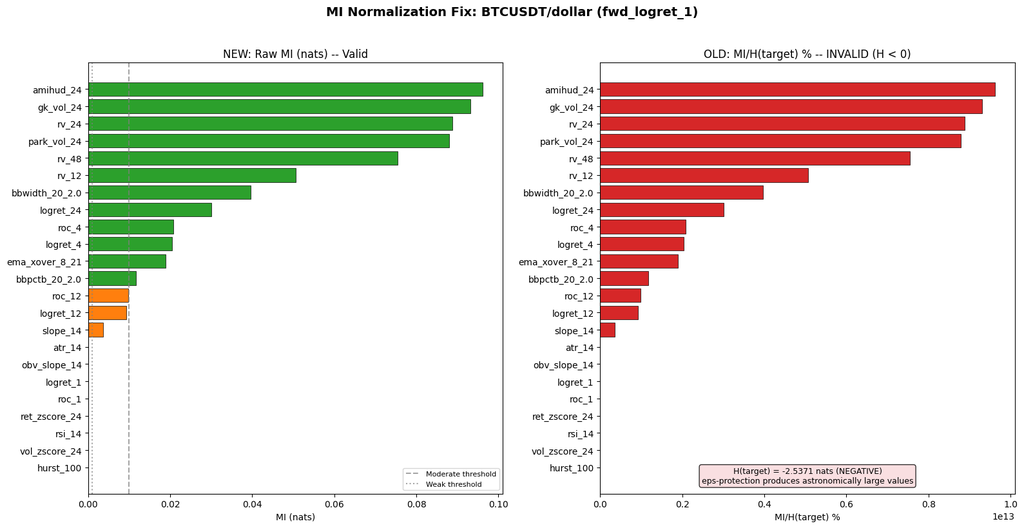

```
Left: Valid raw MI values with qualitative effect-size coloring
  Green = Moderate/Strong, Orange = Weak, Red = Negligible
Right: Invalid MI/H(target) from RC2 -- all values are meaningless
```

```python
"""Section 4, Step 3 -- Visualization: Old vs New normalization side-by-side.

Bar chart comparing the invalid MI/H(target) column with raw MI,
highlighting why the old column was misleading.
"""

fig, axes = plt.subplots(1, 2, figsize=(16, 8))

primary_table_sorted: pd.DataFrame = primary_table.sort_values("MI (nats)", ascending=True)

# Left panel: Raw MI (nats) -- the valid metric
ax_left = axes[0]
colors_left: list[str] = [
    "#2ca02c"
    if classify_mi_effect(mi) in ("Moderate", "Strong")
    else "#ff7f0e"
    if classify_mi_effect(mi) == "Weak"
    else "#d62728"
    for mi in primary_table_sorted["MI (nats)"]
]
ax_left.barh(
    primary_table_sorted["Feature"],
    primary_table_sorted["MI (nats)"],
    color=colors_left,
    edgecolor="black",
    linewidth=0.5,
)
ax_left.set_xlabel("MI (nats)")
ax_left.set_title("NEW: Raw MI (nats) -- Valid")
ax_left.axvline(x=0.01, color="gray", linestyle="--", alpha=0.7, label="Moderate threshold")
ax_left.axvline(x=0.001, color="gray", linestyle=":", alpha=0.7, label="Weak threshold")
ax_left.legend(fontsize=8)

# Right panel: Old MI/H(target) % -- the invalid metric
ax_right = axes[1]
old_vals: np.ndarray = primary_table_sorted["OLD MI/H(target) %"].to_numpy()
colors_right: list[str] = ["#d62728"] * len(old_vals)  # All red -- all invalid
ax_right.barh(
    primary_table_sorted["Feature"],
    old_vals,
    color=colors_right,
    edgecolor="black",
    linewidth=0.5,
)
ax_right.set_xlabel("MI/H(target) %")
ax_right.set_title("OLD: MI/H(target) % -- INVALID (H < 0)")
# Add annotation about the issue
ax_right.text(
    0.5,
    0.02,
    f"H(target) = {compute_target_entropy_gaussian(target_arr):.4f} nats (NEGATIVE)\n"
    "eps-protection produces astronomically large values",
    transform=ax_right.transAxes,
    fontsize=9,
    verticalalignment="bottom",
    horizontalalignment="center",
    bbox={"boxstyle": "round", "facecolor": "#f8d7da", "alpha": 0.8},
)

fig.suptitle(
    "MI Normalization Fix: BTCUSDT/dollar (fwd_logret_1)",
    fontsize=14,
    fontweight="bold",
    y=1.02,
)
plt.tight_layout()
plt.show()

print("Left: Valid raw MI values with qualitative effect-size coloring")
print("  Green = Moderate/Strong, Orange = Weak, Red = Negligible")
print("Right: Invalid MI/H(target) from RC2 -- all values are meaningless")
```

## Section 5: Recommendations

### 5.2 Recommended Changes

| Component | Change | Priority |
| --- | --- | --- |
| `rc2_validation_analysis.py::build_mi_table()` | Replace MI/H(target) % column with "Effect Size" (qualitative scale) | Optional (cosmetic) |
| `validation.py` | No change needed -- does not use entropy normalization | N/A |
| RC2_analysis.md | Add Appendix D documenting this fix | Required |
| Thesis text | Report MI in nats with qualitative effect-size scale | Required |

### 5.3 Why Not Fix `build_mi_table()`?

The `build_mi_table()` method in `rc2_validation_analysis.py` is used only by the RC2 notebook, which has already been run and will not be re-run. Changing the method now would make it inconsistent with the stored RC2 notebook outputs. Instead, we document the issue in Appendix D and use the corrected approach in all future notebooks.

If the method is reused in future research checkpoints (RC3/RC4), it should be updated at that point to use the qualitative MI effect-size scale instead of MI/H(target) %.

### 5.4 Post-Hoc Deviations

**Zero.** This fix changes no decisions, no parameters, and no trial counts. The pre-registration integrity is fully preserved. Trial count remains at 60.

```python
"""Section 5 -- Final summary table for thesis appendix.

Produce the definitive corrected MI table for BTCUSDT/dollar that will be
referenced in Appendix D of RC2_analysis.md.
"""

print("=" * 70)
print("SECTION 5: Definitive corrected MI table for Appendix D")
print("=" * 70)

# Build the clean table for the thesis
primary_table_final: pd.DataFrame = corrected_tables[("BTCUSDT", "dollar")].copy()
thesis_table: pd.DataFrame = primary_table_final[
    ["Feature", "MI (nats)", "Raw p", "BH p", "Significant", "Effect Size", "NEW MI/H_disc(feat) %"]
].rename(columns={"NEW MI/H_disc(feat) %": "MI/H_disc(feat) %"})
thesis_table = thesis_table.sort_values("MI (nats)", ascending=False).reset_index(drop=True)

display(
    thesis_table.style.format(
        {
            "MI (nats)": "{:.6f}",
            "Raw p": "{:.4f}",
            "BH p": "{:.4f}",
            "MI/H_disc(feat) %": "{:.4f}",
        }
    ).set_caption(
        "Corrected MI Table -- BTCUSDT/dollar (fwd_logret_1) -- replaces RC2 Section 3.3 MI/H(target) % column"
    )
)

print(f"\nTotal features: {len(thesis_table)}")
print(f"MI-significant (BH): {int(thesis_table['Significant'].sum())}")
print("Effect size distribution:")
for cat in ["Strong", "Moderate", "Weak", "Negligible"]:
    count = int((thesis_table["Effect Size"] == cat).sum())
    print(f"  {cat:12s}: {count}")
print()
print("This table is referenced in RC2_analysis.md Appendix D.")
print("The invalid MI/H(target) % column has been removed and replaced with:")
print("  1. Effect Size (qualitative scale)")
print("  2. MI/H_disc(feat) % (supplementary, always valid)")
```

```
======================================================================
SECTION 5: Definitive corrected MI table for Appendix D
======================================================================
```

Corrected MI Table -- BTCUSDT/dollar (fwd_logret_1) -- replaces RC2 Section 3.3 MI/H(target) % column

|  | Feature | MI (nats) | Raw p | BH p | Significant | Effect Size | MI/H_disc(feat) % |
| --- | --- | --- | --- | --- | --- | --- | --- |
| 0 | amihud_24 | 0.096231 | 0.0010 | 0.0033 | True | Strong | 4.8503 |
| 1 | gk_vol_24 | 0.093117 | 0.0010 | 0.0033 | True | Strong | 4.6725 |
| 2 | rv_24 | 0.088846 | 0.0010 | 0.0033 | True | Strong | 4.3014 |
| 3 | park_vol_24 | 0.087935 | 0.0010 | 0.0033 | True | Strong | 4.3043 |
| 4 | rv_48 | 0.075464 | 0.0010 | 0.0033 | True | Strong | 3.5423 |
| 5 | rv_12 | 0.050690 | 0.0010 | 0.0033 | True | Strong | 2.5157 |
| 6 | bbwidth_20_2.0 | 0.039595 | 0.0010 | 0.0033 | True | Moderate | 2.0398 |
| 7 | logret_24 | 0.030073 | 0.0050 | 0.0144 | True | Moderate | 1.6136 |
| 8 | roc_4 | 0.020807 | 0.0330 | 0.0758 | False | Moderate | 1.1608 |
| 9 | logret_4 | 0.020429 | 0.0330 | 0.0758 | False | Moderate | 1.1443 |
| 10 | ema_xover_8_21 | 0.018914 | 0.0579 | 0.1212 | False | Moderate | 0.8745 |
| 11 | bbpctb_20_2.0 | 0.011640 | 0.1319 | 0.2527 | False | Moderate | 0.5205 |
| 12 | roc_12 | 0.009758 | 0.1938 | 0.3381 | False | Weak | 0.5330 |
| 13 | logret_12 | 0.009242 | 0.2058 | 0.3381 | False | Weak | 0.5130 |
| 14 | slope_14 | 0.003579 | 0.3027 | 0.4641 | False | Weak | 0.4123 |
| 15 | hurst_100 | 0.000000 | 1.0000 | 1.0000 | False | Negligible | 0.0000 |
| 16 | atr_14 | 0.000000 | 1.0000 | 1.0000 | False | Negligible | 0.0000 |
| 17 | obv_slope_14 | 0.000000 | 1.0000 | 1.0000 | False | Negligible | 0.0000 |
| 18 | logret_1 | 0.000000 | 1.0000 | 1.0000 | False | Negligible | 0.0000 |
| 19 | roc_1 | 0.000000 | 1.0000 | 1.0000 | False | Negligible | 0.0000 |
| 20 | ret_zscore_24 | 0.000000 | 1.0000 | 1.0000 | False | Negligible | 0.0000 |
| 21 | rsi_14 | 0.000000 | 1.0000 | 1.0000 | False | Negligible | 0.0000 |
| 22 | vol_zscore_24 | 0.000000 | 1.0000 | 1.0000 | False | Negligible | 0.0000 |

```
Total features: 23
MI-significant (BH): 8
Effect size distribution:
  Strong      : 6
  Moderate    : 6
  Weak        : 3
  Negligible  : 8

This table is referenced in RC2_analysis.md Appendix D.
The invalid MI/H(target) % column has been removed and replaced with:
  1. Effect Size (qualitative scale)
  2. MI/H_disc(feat) % (supplementary, always valid)
```